# Predictive Sensory Modelling

## Model Statistics

### Gradient Boosted Model (GBM)

Gradient boosted model generates relative variable importance scores for each characteristic. It is possible to filter aroma causing compounds by aroma activity values that are based on estimates for odor threshold concentrations to reduce the number of variables. That is, only including aroma compounds with concentrations that exceed the theoretical odor threshold in at least one sample group. For gradient-boosting machines the variable importance repre-sents the marginal effect of that chemical including the interac-tion effects with other chemicals. This value is scaled between 0and 100 where 0 is a not an important predictor and 100 is animportant predictor.

```r
#gbm model

model_gbm <-  gbm(sensory_data$floral_AR ~.,
                  data = metabolite_data,
                  distribution = "gaussian",
                  cv.folds = 10,
                  shrinkage = c(0.05),
                  n.minobsinnode = c(10),
                  n.trees = c(500),
                  interaction.depth = c(5),
                  set.seed(123))

model_summary <- summary.gbm(model_gbm) %>%
                 mutate(var = (gsub("`","",var))) %>%
                 rename("species" = "var", "floral_aroma_gbm" = "rel.inf")
```

[figure not shown]

### Bayesian Model

The correlation of compounds to aroma intensity can be predicted by the beta coefficient from Bayesian modelling.In BayesA, the beta coefficients indicate the individual additive effect of that chemical free of interactions. This coefficient predicts if achemical is important for enhancing the flavor attribute (positive value) or decreasing the flavor attribute (negative value).

```r
# BayesA model

y <- sensory_data$floral_AR

ETA <- list(list(X = metabolite_data, model = 'BayesA'))

fit_BA <- BGLR(y = y, ETA = ETA, nIter = 3000, burnIn = 1000,
               thin = 3, saveAt = '', df0 = 5, S0 = NULL,
               weights = NULL, R2 = 0.5)
# add Bayes A beta coefficients to model summary
model_plot_data <- model_summary %>%
                  mutate(b_floral_aroma = fit_BA$ETA[[1]]$b) %>%
                  left_join(genotype_table)
```

Beta coefficients from the model are added to the table containing relative variable importance from the previous model. Finally, GBM values (x-axis) and beta-coefficients (y-axis) can be plotted to visualise the determinants of each characteristic.

### Model Plot

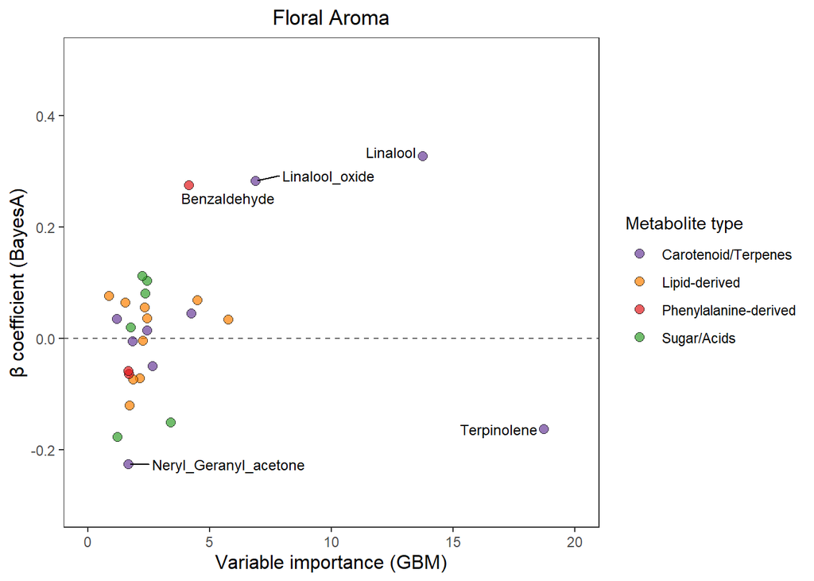

```r
# plotting

label_subset <- model_plot_data %>%
                subset(b_floral_aroma > 0.2 | b_floral_aroma < -0.18) %>%
                bind_rows(subset(model_plot_data, floral_aroma_gbm > 10)) %>%
                distinct()
#choose colours

my_colours <- c("#6a3d9a", "#ff7f00", "#e31a1c", "#33a02c", "#1f78b4")

#plot PCA coords using ggplot

ggplot(model_plot_data) +
  aes(x = floral_aroma_gbm, y = b_floral_aroma, fill = Class2, label = species) +
  geom_hline(yintercept = 0, alpha = 0.6,
             linetype="dashed", linewidth=0.5) +
  scale_fill_manual(values = my_colours)+
  xlim(0, 20) + ylim(-0.3,0.5) +
  geom_point(shape = 21,alpha = 0.7, size=2.5) +
  theme_bw() + theme(plot.background = element_blank(),
                     panel.grid.major = element_blank(),
                     panel.grid.minor = element_blank(),
                     axis.title = element_text(size=12),
                     plot.title = element_text(hjust = 0.5)) +
  geom_text_repel(data = label_subset,
                  x=label_subset$floral_aroma_gbm, y=label_subset$b_floral_aroma,
                  inherit.aes = F,
                  label = label_subset$species,
                  hjust=-0.15, vjust=0.5, size=3.2)+
  labs( x="Variable importance (GBM)",
        y="β coefficient (BayesA)", fill="Metabolite type",
        title = "Floral Aroma")
```